# Práctica Calificada N°2

Enrique Zevallos

12 de junio de 2017

## Ejercicio 1

Hacemos uso de is.finite, is.infinite, is.nan, entre otros…, con el fin de filtrar ciertos valores dentro de estructuras como vectores, matrices, etc.

### (a)

En primer lugar, asignamos a **f1**, el vector indicado

```r
f1 <- c (13563, -14156, -14319, 16981, 12921, 11979, 9568, 8833, -12968, 8133)
```

Deseamos imprimir solo los valores de f1 que cumplan con la condición *f1^75* no es Inf

```r
f1 [c (is.finite (f1 ^ 75))]
```

```
## [1] 11979  9568  8833  8133
```

Asimismo, los valores de f1, excluyendo aquellos en los que f1^75 es -Inf

```r
f1 [c (!(f1 < 0 & is.infinite (f1 ^ 75)))]
```

```
## [1] 13563 16981 12921 11979  9568  8833  8133
```

### (b)

Almacenamos la matriz **varMatriz** con los valores indicados

```r
varMatriz <- matrix (c (77875.4, -35466.25, -39803.81, 27551.45, -73333.85, 55976.34, 23764.3, 36599.69, 76694.82, -36478.88, -70585.69, 47032), nrow = 3, ncol = 4)
```

Hacemos uso de la función *which* que ha de devolvernos los índices para los cuales se cumple la condición que indiquemos.El argumento arr.ind, toma en cuenta las dimensiones de la matriz, mientras que prescindir de él, nos devolverá el orden absoluto del índice.

En este primer caso, los índices que queremos encontrar son de aquellas entradas de **varMatriz** que son NaN cuando se eleva a 65 y se divide entre infinito

```r
which (is.nan ( (varMatriz ^ 65) / (1 / 0)), arr.ind = TRUE)
```

```
##      row col
## [1,]   1   1
## [2,]   2   2
## [3,]   3   2
## [4,]   3   3
## [5,]   2   4
```

En el segundo caso, pide devolver los valores de **varMatriz** que NO son NaN cuando elevamos **varMatriz** a una potencia de 67 y le añadimos Inf, es decir los valores cuyos índices sean,

```r
which (!is.nan (varMatriz ^ 67 + (1 / 0)), arr.ind = TRUE)
```

Estos serán:

```r
varMatriz[ !c (is.nan (varMatriz ^ 67 + (1 / 0)))]
```

```
##  [1]  77875.40 -35466.25 -39803.81  27551.45  55976.34  23764.30  36599.69
##  [8]  76694.82 -36478.88  47032.00
```

Además, nos piden confirmar que esto es idéntico a identificar aquellos valores en **varMatriz** que, cuando se elevan a una potencia de 67, no son iguales al infinito negativo. Mediante el siguiente comando, encontramos dichos valores, y podemos confirmar que son los mismos.

```r
which (! (is.infinite (varMatriz ^ 67) & varMatriz < 0), arr.ind = TRUE)
```

```
##       row col
##  [1,]   1   1
##  [2,]   2   1
##  [3,]   3   1
##  [4,]   1   2
##  [5,]   3   2
##  [6,]   1   3
##  [7,]   2   3
##  [8,]   3   3
##  [9,]   1   4
## [10,]   3   4
```

Que como podemos comprobar, sí son los mismos que la expresión mencionada previamente…

[output not shown]

Finalmente, nos piden identificar aquellos valores en **varMatriz**, que son infinito negativo *O* finito cuando **varMatriz** se eleva a una potencia de 67.

```r
which ( (is.finite (varMatriz ^ 67) |(varMatriz < 0 & is.infinite (varMatriz ^ 67) ) ), arr.ind = TRUE)
```

```
##      row col
## [1,]   2   1
## [2,]   3   1
## [3,]   1   2
## [4,]   2   2
## [5,]   1   3
## [6,]   2   3
## [7,]   1   4
## [8,]   2   4
```

### (c)

Consideremos la línea de código siguiente:

```r
f2 <- c (4.3, 2.2, NULL, 2.4, NaN, 3.3, 3.1, NULL, 3.4, NA)
```

Dadas las siguientes afirmaciones, decidir su veracidad o falsedad:

- **La longitud de f2 es 8.** (Esto es **verdadero**, ya que R no considera los argumentos NULL para computar la longitud)

#### Prueba

```r
length(f2)
```

```
## [1] 8
```

- **Llamando a which (x = is.na (x = f2)), no resultará en 4 y 8.** (Esto es **falso**, ya que el resultado sí será 4 y 8, pues al no considerar los *NULL*, los valores que pueden considerarse *na* se encuentran en dichas posiciones)

#### Prueba

```r
which (x = is.na (x = f2))
```

```
## [1] 4 8
```

- **Verificando is.null (x = f2), proporciona la localización de dos valores *NULL*, presentes.** (Esta afirmación es **falsa** ya que lo único que hará la función es verificar si el vector **f2** es nulo o no. En este caso, devolverá el resultado **FALSE**)

#### Prueba

```r
is.null (x = f2)
```

```
## [1] FALSE
```

## Ejercicio 2

#### (a)

Dada una lista, cuyos miembros son vectores de cadena de caracteres de diferentes longitudes, hacemos uso de la función *lapply* con el fin de pegar un signo de exclamación al final de cada elemento de cada miembro, con una cadena vacía como caracter de separación.

```r
f3 <- list ("a", c ("b", "c", "d", "e"), "f", c ("g", "h", "i"))
lapply(f3, paste, "!", sep = "")
```

```
## [[1]]
## [1] "a!"
##
## [[2]]
## [1] "b!" "c!" "d!" "e!"
##
## [[3]]
## [1] "f!"
##
## [[4]]
## [1] "g!" "h!" "i!"
```

#### (b)

Debemos escribir una función llamada *geolista*, que puede buscar a través de una lista especificada y calcular las medias geométricas de cada miembro.

- La función debe definir y utilizar una función de ayuda interna que devuelve la media geométrica de un argumento vectorial
- Suponer que la lista solo puede tener vectores numéricos o matrices numéricas como sus miembros. La función debe contener un bucle apropiado para inspeccionar a cada miembro de la lista a la vez.
- Si el miembro de la lista es un vector, calcular la media geométrica de ese vector, sobrescribiendo el miembro con el resultado, que debe ser un solo número.
- Si el miembro de la lista es una matriz, utilice un bucle implícito para calcular la media geométrica de cada fila de la matriz, sobrescribiendo el miembro con los resultados.
- La lista final debe ser devuelta al usuario

La función tendrá la forma siguiente:

```r
geolista <- function(l){
  g <- function (n){
    return (prod (n) ^ (1 / length (n)))
  }
#La función ha de devolver la media geométrica del argumento vectorial

  for(i in 1:length(l)){
    if(!is.matrix(l[[i]])){
      l[[i]] <- g(l[[i]])
    } else {
      l[[i]] <- apply(l[[i]],1,g)
    }
  }
#Tendremos el bucle que, dependiendo de si es una matriz o no, aplica la función g de manera distinta, usando la notación [[]]

  return(l)
#Devolvemos la lista final al usuario
}
```

```r
f4 <- list(1 : 3, matrix (c (3.3, 3.2, 2.8, 2.1, 4.6, 4.5, 3.1, 9.4), 4, 2), matrix (c (3.3, 3.2, 2.8, 2.1, 4.6, 4.5, 3.1, 9.4), 2, 4))
geolista (f4)
```

```
## [[1]]
## [1] 1.817121
##
## [[2]]
## [1] 3.896152 3.794733 2.946184 4.442972
##
## [[3]]
## [1] 3.388035 4.106080
```

```r
f5 <- list (1 : 9, matrix (1 : 9, 1, 9), matrix (1 : 9, 9, 1), matrix (1 : 9, 3, 3))
geolista (f5)
```

```
## [[1]]
## [1] 4.147166
##
## [[2]]
## [1] 4.147166
##
## [[3]]
## [1] 1 2 3 4 5 6 7 8 9
##
## [[4]]
## [1] 3.036589 4.308869 5.451362
```

### (c)

La primera puede ser la función *integrate*, por ejemplo:

```r
integrate (f = foo, lower = 0, upper = 1)
```

```
## 1.301169 with absolute error < 1.4e-14
```

## Ejercicio 3

### (a)

Supongamos que representamos el triángulo de Pascal como una lista, donde el elemento n es la *n-ésima* fila del triángulo. Por ejemplo, el triángulo de Pascal a la profundidad cuatro sería dado por:

```
## [[1]]
## [1] 1
##
## [[2]]
## [1] 1 1
##
## [[3]]
## [1] 1 2 1
##
## [[4]]
## [1] 1 3 3 1
```

```r
pascalTriangle <- function (h) {
  lapply(0:h, function (i) choose (i, 0:i))
}
pascalTriangle (10)
```

```
## [[1]]
## [1] 1
##
## [[2]]
## [1] 1 1
##
## [[3]]
## [1] 1 2 1
##
## [[4]]
## [1] 1 3 3 1
##
## [[5]]
## [1] 1 4 6 4 1
##
## [[6]]
## [1]  1  5 10 10  5  1
##
## [[7]]
## [1]  1  6 15 20 15  6  1
##
## [[8]]
## [1]  1  7 21 35 35 21  7  1
##
## [[9]]
## [1]  1  8 28 56 70 56 28  8  1
##
## [[10]]
##  [1]   1   9  36  84 126 126  84  36   9   1
##
## [[11]]
##  [1]   1  10  45 120 210 252 210 120  45  10   1
```

Como podemos comprobar, en la undécima fila, los valores son aquellos obtenidos según el coeficiente binomial de 10 en *i*, cuando *i* va de 0 a 10.

```r
for (i in 0:10) print (choose (10,i))
```

```
## [1] 1
## [1] 10
## [1] 45
## [1] 120
## [1] 210
## [1] 252
## [1] 210
## [1] 120
## [1] 45
## [1] 10
## [1] 1
```

### (b)

Supongamos que necesitamos todas las *2^n* secuencias binarias de longitud *n*. Una forma de generarlas es con bucles anidados. Por ejemplo, el siguiente código genera una matriz binseq, donde cada fila es una secuencia binaria diferente de longitud tres.

```r
binseq <- matrix (nrow = 8, ncol = 3)
r <- 0
for (i in 0:1) {
  for (j in 0:1) {
    for (k in 0:1) {
      r <- r + 1
      binseq [r,] <- c (i, j, k)
    }
  }
}
binseq
```

```
##      [,1] [,2] [,3]
## [1,]    0    0    0
## [2,]    0    0    1
## [3,]    0    1    0
## [4,]    0    1    1
## [5,]    1    0    0
## [6,]    1    0    1
## [7,]    1    1    0
## [8,]    1    1    1
```

Sin embargo, este enfoque resulta tedioso para grandes valores de *n*. Una alternativa es usar recursión. Con el fin de escribir una función *binseq* que tome como entrada un entero *n*, y devuelva una matriz que contenga todas las secuencias binarias de longitud *n*, como filas de la matriz. En el programa es particularmente útil el uso de las funciones *cbind* y *rbind* que toman secuencias de vectores, matrices o incluso *data frames* y combinan por *columnas* o *filas* respectivamente. Tendremos la siguiente función:

```r
binseq <- function (n) {
   if (n == 1) {
   A <- matrix (0 : 1, nrow = 2, ncol = 1)
   return (A)
}else{
  A <- binseq (n-1)
  B <- rbind (cbind (0, A), cbind (1, A))
  return (B)
   }
}

binseq (3)
```

```
##      [,1] [,2] [,3]
## [1,]    0    0    0
## [2,]    0    0    1
## [3,]    0    1    0
## [4,]    0    1    1
## [5,]    1    0    0
## [6,]    1    0    1
## [7,]    1    1    0
## [8,]    1    1    1
```

## Ejercicio 4

### (a)

Corre:

```r
ggplot (data = mpg)
```

### (b)

¿Cuántas filas hay en *mpg*? ¿Cuántas columnas?

```r
nrow (mpg)
```

```
## [1] 234
```

```r
ncol (mpg)
```

```
## [1] 11
```

### (c)

¿Qué describe la variable drv?

```r
?mpg
```

Según la ayuda *?mpg*, la variable *drv* nos indica si el automóvil es tracción posterior (r: *rear wheel drive*), tracción delantera (f: *fron-wheel drive*), o 4x4 (4: *4WD*)

### (d)

Realizar un diagrama de dispersión entre *hwy* y *cyl* (es decir entre millas por galón en la carretera, y el número de cilindros)

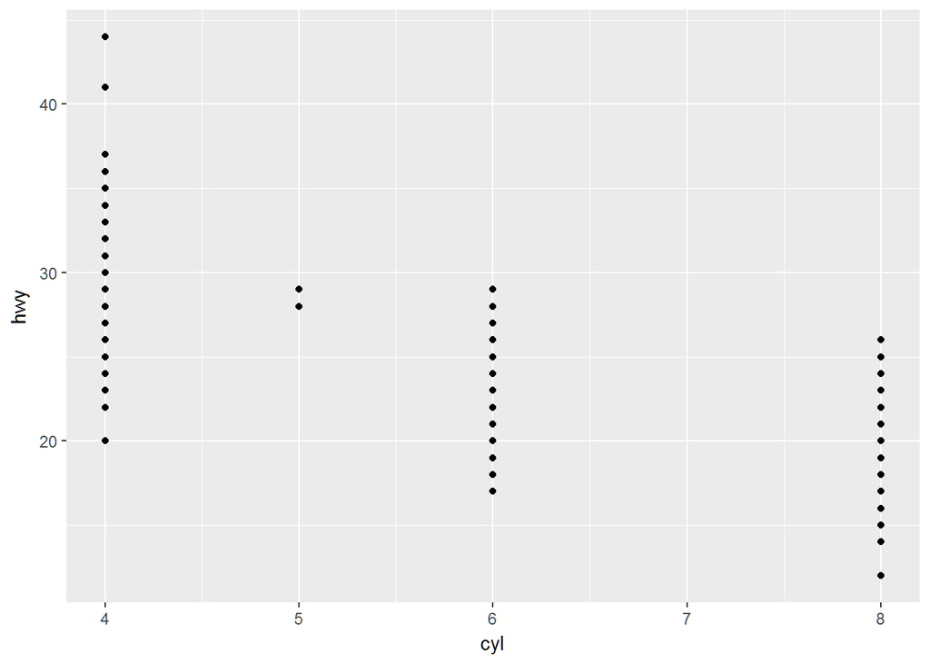

```r
e <- ggplot (mpg, aes (cyl, hwy))
e + geom_point ()
```

### (e)

Ahora bien, nos piden explicar qué sucede si hacemos un diagrama de dispersión entre *class* y *drv*.

```r
p <- ggplot (mpg, aes (class, drv))
p + geom_point ()
```

Esta gráfica carece de sentido, ya que ambas variables son categóricas, los puntos estarán sobrepuestos y por tanto solo visualizaremos cualquier variable con esa particular combinación de clases. El uso de geom_scatter debería arreglarlo.

### (f)

¿Qué ha salido mal en el siguiente código? ¿Por qué los puntos no son azules?

```r
ggplot (data = mpg) + geom_point (mapping = aes (x = displ, y = hwy, color = "blue"))
```

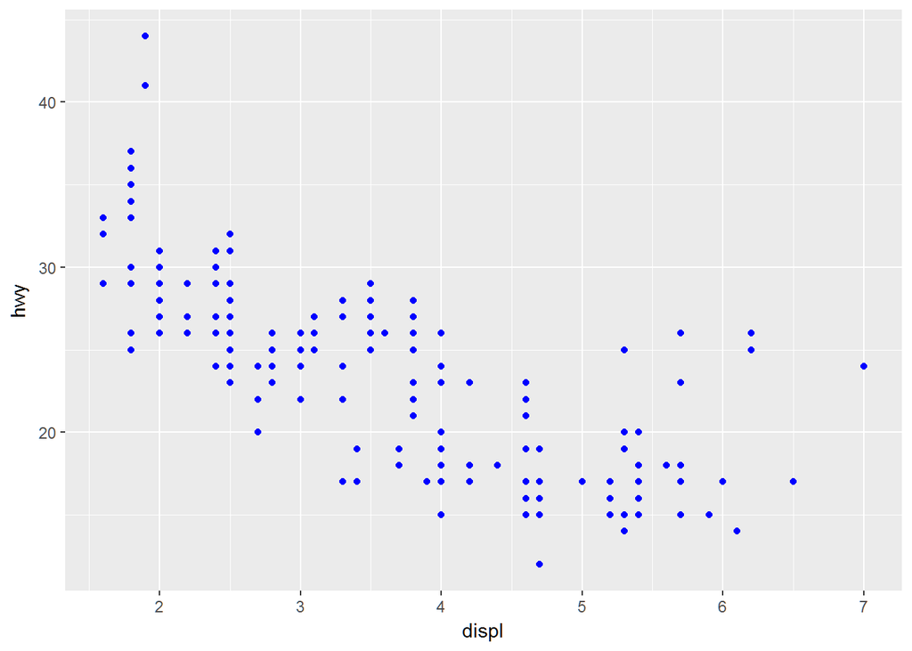

```r
ggplot (data = mpg) + geom_point (mapping = aes (x = displ, y = hwy), color = "blue")
```

### (g)

¿Qué variables en mpg son categóricas? ¿Qué variables son continuas? Esta información la vemos simplemente ingresando el nombre del data-set:

```r
mpg
```

```
## # A tibble: 234 x 11
##    manufacturer      model displ  year   cyl      trans   drv   cty   hwy
##           <chr>      <chr> <dbl> <int> <int>      <chr> <chr> <int> <int>
##  1         audi         a4   1.8  1999     4   auto(l5)     f    18    29
##  2         audi         a4   1.8  1999     4 manual(m5)     f    21    29
##  3         audi         a4   2.0  2008     4 manual(m6)     f    20    31
##  4         audi         a4   2.0  2008     4   auto(av)     f    21    30
##  5         audi         a4   2.8  1999     6   auto(l5)     f    16    26
##  6         audi         a4   2.8  1999     6 manual(m5)     f    18    26
##  7         audi         a4   3.1  2008     6   auto(av)     f    18    27
##  8         audi a4 quattro   1.8  1999     4 manual(m5)     4    18    26
##  9         audi a4 quattro   1.8  1999     4   auto(l5)     4    16    25
## 10         audi a4 quattro   2.0  2008     4 manual(m6)     4    20    28
## # ... with 224 more rows, and 2 more variables: fl <chr>, class <chr>
```

Como es fácil observar, las variables categóricas vienen a ser

- manufacturer (fabricante)
- model (nombre del modelo)
- trans (tipo de transmisión)
- drv (tipo de tracción)
- fl (tipo de combustible)

La única variable continua es displ (desplazamiento del motor, en litros). Los demás, year, cyl, cty y hwy toman valores discretos.

### (h)

Asigne una variable continua a **color**, **size**, y **shape**. ¿Cómo se comportan estas estéticas de manera diferente para variables categóricas y continuas?

- **shape** no puede mapearse a una variable continua, ya que las formas no pueden ordenarse
- **size** puede usarse para asignar un valor al tamaño de la marca en la gráfica
- **color** puede asignarse para definir la saturación de una marca en la gráfica

### (i)

¿Qué sucede si se asigna la misma variable a estéticas múltiples? No hay ningún problema, por ejemplo, podemos asignar la **forma** y el **color** para una sola variable.

### (j)

¿Qué hace la estética **stroke**? ¿Con qué formas trabaja? Stroke maneja el grosor del borde para aquellas formas que tengan (borde).

### (k)

¿Qué sucede si se asigna una estética a algo que no sea un nombre de variable como aes (color = displ < 5)? Los mapeos estéticos son tratados como expresiones en el contexto de la *data*. Por tanto se evaluará la expresión, y se graficará el resultado.

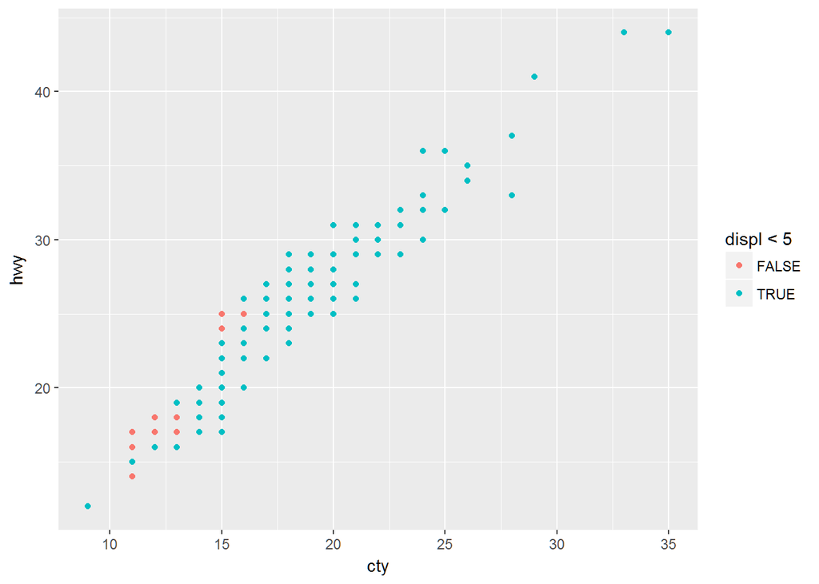

```r
ggplot(data = mpg) + geom_point(aes(x = cty, y = hwy, color = displ < 5))
```

### (l)

Usando facets…

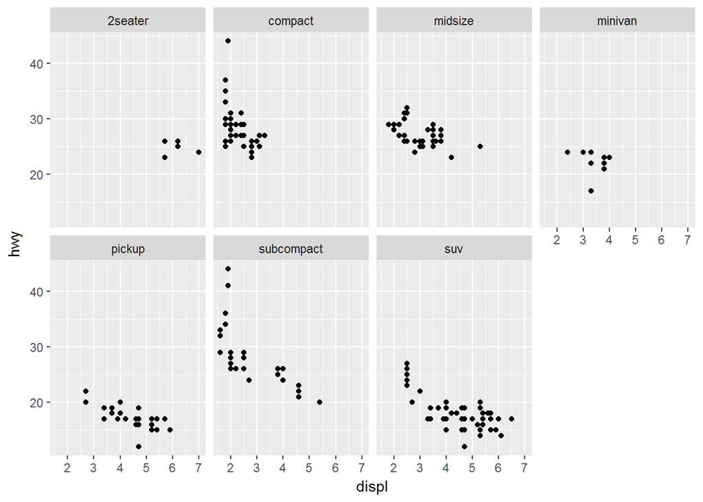

```r
ggplot (data = mpg) + geom_point (mapping = aes (x = displ, y = hwy)) + facet_wrap (~ class, nrow = 2)
```

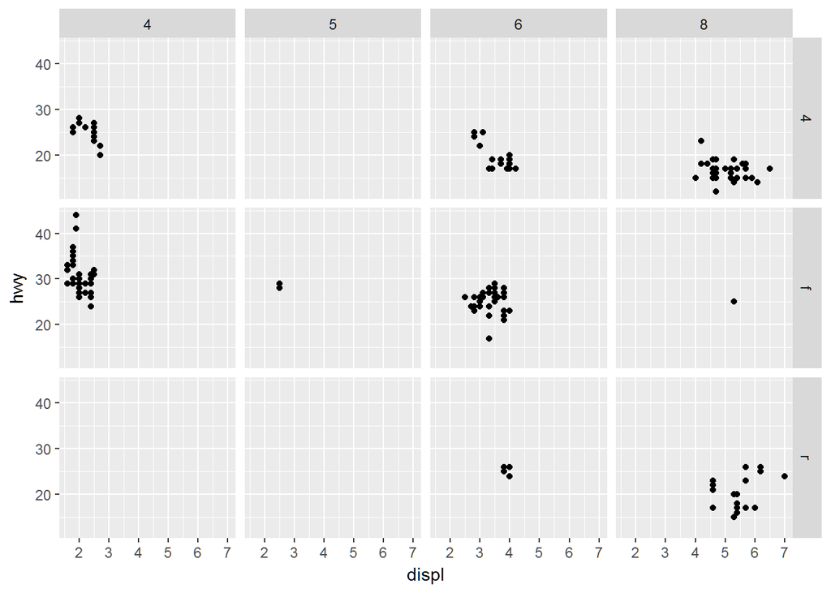

```r
ggplot (data = mpg) + geom_point (mapping = aes (x = displ, y = hwy)) + facet_grid (drv ~ cyl)
```

- ¿Qué sucede si hace **facets** en una variable continua? Tendremos una fila o columna, por cada valor único que tome la variable. Esto puede resultar engorroso si la variable toma un gran rango de valores.
- ¿Qué significan las celdas vacías en el gráfico con facet_grid (drv ~ cyl)? Significa que dicha combinación entre drv y cyl no se dio en el data-set.
- ¿Cómo se relacionan con el gráfico siguiente?

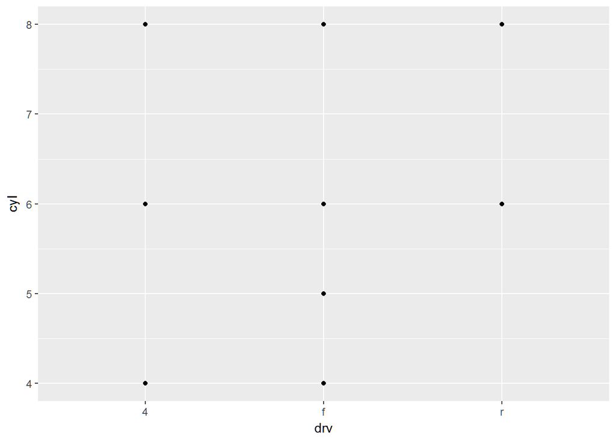

```r
ggplot (data = mpg) + geom_point (mapping = aes (x = drv, y = cyl))
```

Se relaciona ya que el facet_grid generó una grilla de drv vs. cyl. Que posteriormente hemos graficado arriba. Observamos que coinciden las áreas con ocurrencias, y las áreas vacías ya que están íntimamente relacionados.

- ¿Qué gráficos hace el siguiente código? ¿Qué hace el punto “.”?

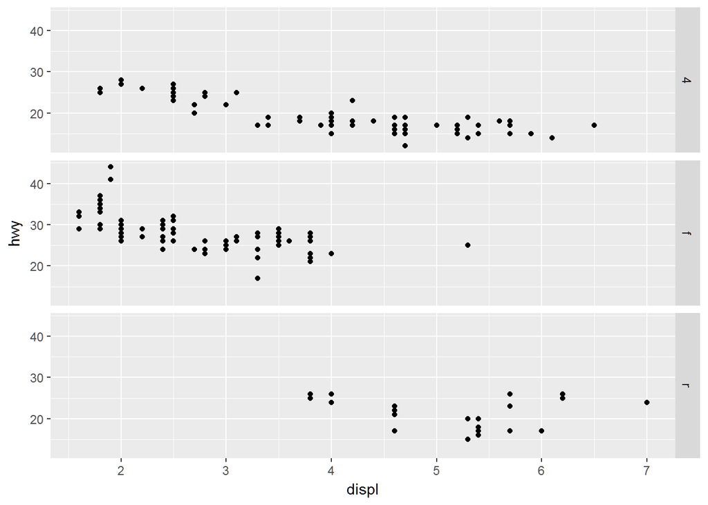

```r
ggplot (data = mpg) + geom_point (mapping = aes (x = displ, y = hwy)) + facet_grid (drv ~ .)
```

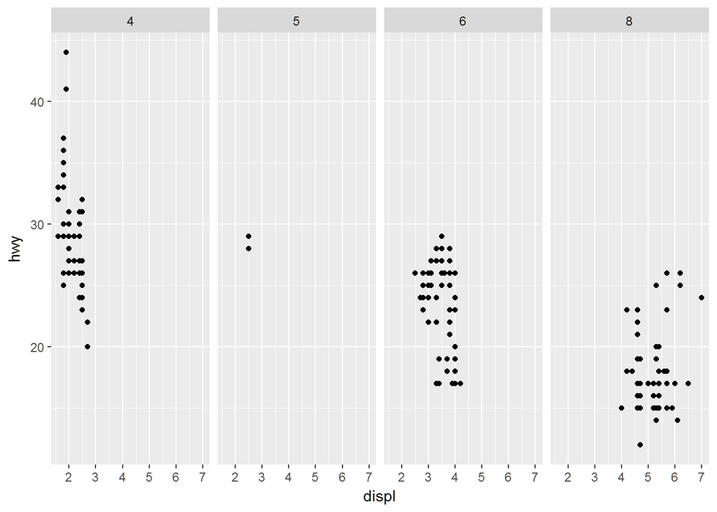

```r
ggplot (data = mpg) + geom_point (mapping = aes (x = displ, y = hwy)) + facet_grid (. ~ cyl)
```

El punto sirve para que solo tengamos un *facet* en una dimensión. Es necesario ya que las fórmulas de sólo un lado pueden resultar problemáticas a veces.

### (m)

Leer ?facet_wrap y contestar…

- **¿Qué hace nrow?** Determina el número de filas.
- **¿Qué hace ncol?** Determina el número de columnas.
- **¿Qué otras opciones controlan la disposición gráfica?** La opción *dir* .
- **¿Qué hace que facet_grid no tenga los argumentos nrow y ncol?** El hecho que ya estén implicados debido a las variables de facetas.

### (n)

Cuando se utiliza facet_grid () normalmente se debe colocar la variable con más niveles únicos en las columnas. ¿Por qué? Esto es debido a que la mayoría de *displays* son más anchos que altos.

## Ejercicio 5

### (a)

¿Qué ocurre con un factor, cuando se modifica sus niveles?

```r
f1 <- factor (letters)
f1
```

```
##  [1] a b c d e f g h i j k l m n o p q r s t u v w x y z
## Levels: a b c d e f g h i j k l m n o p q r s t u v w x y z
```

```r
levels (f1) <- rev (levels (f1))
f1
```

```
##  [1] z y x w v u t s r q p o n m l k j i h g f e d c b a
## Levels: z y x w v u t s r q p o n m l k j i h g f e d c b a
```

El código anterior modifica los factores de *f1* y los pone en reversa. Como podemos observar, rev ha revertido ambos el vector y los niveles. En este caso en particular, no habrá problema ya que los niveles en su totalidad son los mismos, pero habría que tener cuidado al agregar o quitar alguno.

### (b)

¿Qué hace este código? ¿Cómo difieren f2 y f3 de f1?

```r
f2 <- rev (factor (letters))
f3 <- factor (letters, levels = rev (letters))
```

En f2, el factor revirtió al vector, pero los niveles se mantienen intactos. Imprimirá z y x… pero los niveles serán a b c… . En el caso de f3, este será un factor. Se revertirán los niveles, pero no el vector. Por tanto dará como resultado a b c…, con niveles x y z… . Como podemos observar, difiere del f1 que tuvo en una primera instancia un vector a b c… con niveles a b c… y luego un vector z y x… con niveles z y x… .

### (c)

¿Qué atributos posee un data frame?

- names
- col.names / row.names
- class

### (d)

¿Qué hace as.matrix () cuando se aplica a un data frame con columnas de diferentes tipos? Los fuerza al mismo tipo, utilizando una serie de reglas de coerción.

### (e)

¿Se puede tener un data frame de datos con 0 filas? ¿ Qué hay de 0 columnas? Sí, es perfectamente factible tener un data frame completamente vacío.

### (f)

¿Qué devuelve *upper.tri*? ¿Cómo funciona para obtener subconjuntos de una matriz con esta función? ¿Necesitamos reglas de subconjunto adicionales para describir su comportamiento? Devuelve una matriz lógica del mismo tamaño de la matriz con resultado TRUE en el triángulo superior o inferior. La misma que es usada para obtener subconjuntos de la matriz. Al hacerlo, no necesitamos reglas adicionales de subconjuntos ya que se trata de vectores.

### (g)

Implemente su propia función que extrae las entradas diagonales de una matriz (Debe comportarse como diag (x) donde x es una matriz).

```r
n_diag <- function (m){
  require(dplyr)
  require(magrittr)

  m %>%
    ncol %>%
    seq_len %>%
    l(x -> cbind(x,x)) %>%
    m[.]
  }
```

### (h)

¿Cómo cambiarías aleatoriamente las columnas de un data frame? (Esta es una técnica importante en los bosques aleatorios). ¿Puedes permutar las filas y las columnas simultáneamente en un solo paso?

### (i)

¿Cómo seleccionarías una muestra aleatoria de *m* filas de un data frame de datos? ¿Qué pasa si la muestra tiene que ser contigua (es decir, con una fila inicial, una fila final y cada fila entre ellas)?

```r
contig_samp <- function (df, m) {
  df %>%
    nrow %>%
    subtract (m) %>%
    sample (1) %>%
    add (seq_len (m)) %>%
    df [.,]
}
```

### (j)

¿Cómo podrías colocar las columnas en un data frame de datos en orden alfabético?

```r
mpg [order (names (mpg))]
```

```
## # A tibble: 234 x 11
##      class   cty   cyl displ   drv    fl   hwy manufacturer      model
##      <chr> <int> <int> <dbl> <chr> <chr> <int>        <chr>      <chr>
##  1 compact    18     4   1.8     f     p    29         audi         a4
##  2 compact    21     4   1.8     f     p    29         audi         a4
##  3 compact    20     4   2.0     f     p    31         audi         a4
##  4 compact    21     4   2.0     f     p    30         audi         a4
##  5 compact    16     6   2.8     f     p    26         audi         a4
##  6 compact    18     6   2.8     f     p    26         audi         a4
##  7 compact    18     6   3.1     f     p    27         audi         a4
##  8 compact    18     4   1.8     4     p    26         audi a4 quattro
##  9 compact    16     4   1.8     4     p    25         audi a4 quattro
## 10 compact    20     4   2.0     4     p    28         audi a4 quattro
## # ... with 224 more rows, and 2 more variables: trans <chr>, year <int>
```

### (k)

Enumera tres formas en que un entorno difiere de una lista.

- Todo debe tener un nombre único
- Los entornos tienen ancestros
- No existe un orden

### (l)

Usando parent.env () y un bucle (o una función recursiva), verifica que los predecesores de globalenv () incluyan baseenv () y emtpyenv (). Utiliza la misma idea básica para implementar tu propia versión de search ().